# P4-CP1

# Os dados

Os dados que vamos trabalhar são uma amostra de atividades (alteracao) de arquivos com uma certa extensao que estao hospedadas no GitHub, para isso, nos é diponibilizado dados como: - A extensao do arquivo; - Quantidade de usuarios que modificaram arquivos de determinada extensao e - Dia, mes e ano da alteracao. As datas variam de janeiro de 2016 a maio de 2017.

```r
java_repos <- dados_github %>%
  filter(file_extension == 'java') %>%
    mutate(week_day = wday(ymd(paste(the_year, formatC(the_month, width=2, flag="0"), formatC(month_day, width=2, flag="0")))))

cpp_repos <- dados_github %>%
  filter(file_extension == 'cpp') %>%
    mutate(week_day = wday(ymd(paste(the_year, formatC(the_month, width=2, flag="0"), formatC(month_day, width=2, flag="0")))))
```

# Alterando os dados disponibilizados

Como os dados disponibilizados nao oferecem o dia da semana e as perguntas sao em cima dessa variavel, foi utilizada uma biblioteca externa (lubridate) para conseguir capturar esse dado.

# Respondendo as perguntas:

## 1. Para cada uma delas, há uma diferença significativa na sua popularidade durante a semana e durante o fim de semana? Essa diferença é grande?

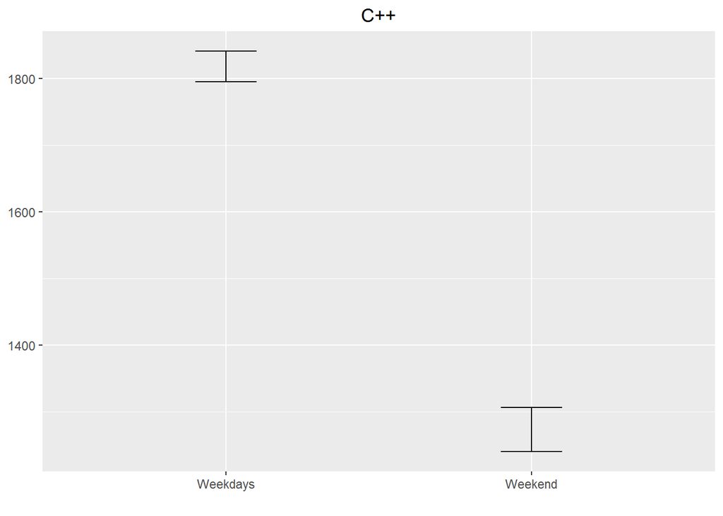

```r
#em C++
cpp_weekday.median = bootstrap(cpp_repos_wkday,
                            median(users),
                            R= 4000)
cpp_weekday.CI = cpp_weekday.median  %>%
  CI.percentile(probs = c(.025, .975))

cpp_wkend.median = bootstrap(cpp_repos_wkend,
                            median(users),
                            R= 4000)
cpp_weekend.CI = cpp_wkend.median  %>%
  CI.percentile(probs = c(.025, .975))


data.frame(rbind(cpp_weekday.CI, cpp_weekend.CI)) %>%
   ggplot(aes(x= c("Weekdays", "Weekend"), ymin = X2.5., ymax = X97.5.)) +
  geom_errorbar(width = .2) + ggtitle("C++") + theme(plot.title = element_text(hjust = 0.5)) + labs(x="")
```

O grafico acima mostra que existe uma grande diferença nos intervalos das medianas de repositorios em com 95% de confiança que sofreram alterações em arqivos C++ em dias de semana e final de semana, onde sofreram mais alteracoes em dia de semana, mais a frente verificaremos quão maior é essa diferença.

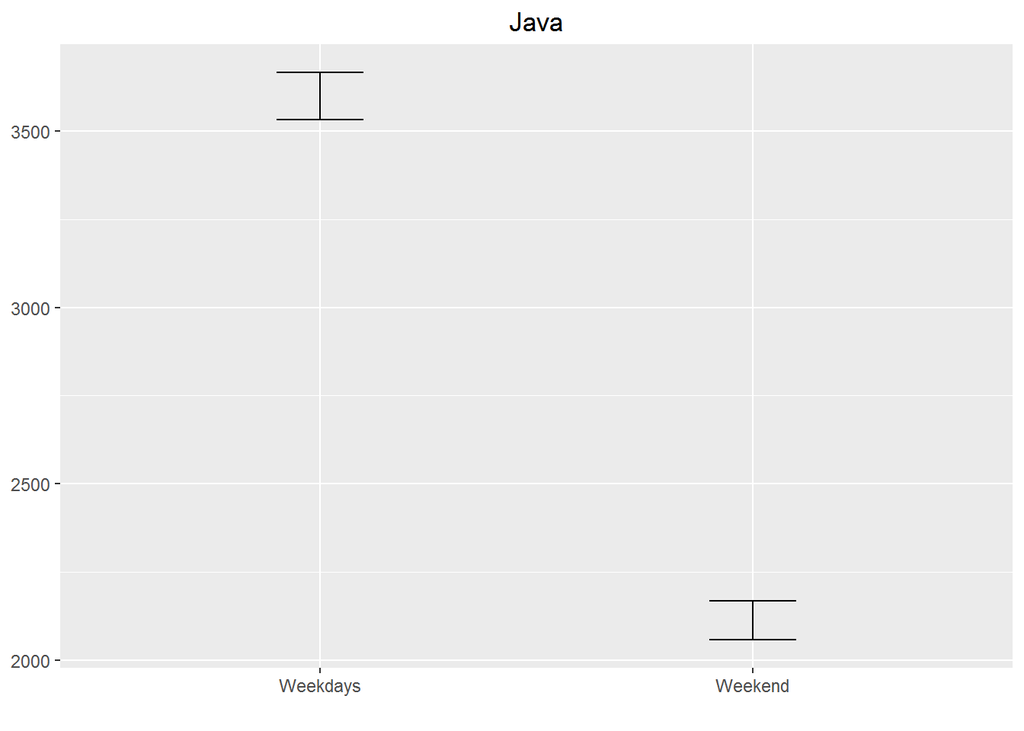

```r
#para Java

java_wkday.median = bootstrap(java_repos_wkday,
                            median(users),
                            R= 4000)
java_wkday.CI = java_wkday.median  %>%
  CI.percentile(probs = c(.025, .975))

java_wkend.median = bootstrap(java_repos_wkend,
                            median(users),
                            R= 4000)
java_wkend.CI = java_wkend.median  %>%
  CI.percentile(probs = c(.025, .975))


data.frame(rbind(java_wkday.CI, java_wkend.CI)) %>%
   ggplot(aes(x= c("Weekdays", "Weekend"), ymin = X2.5., ymax = X97.5.)) +
  geom_errorbar(width = .2) + ggtitle("Java") + theme(plot.title = element_text(hjust = 0.5)) + labs(x="")
```

O grafico acima mostra que existe uma grande diferença nos intervalos das medianas de repositorios com 95% de confiança que sofreram alterações em arquivos Java em dias de semana e final de semana, onde sofreram mais alteracoes em dia de semana.

### Quantificando a diferenca

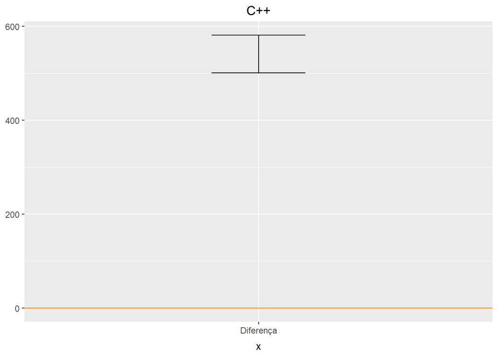

```r
cpp_repos_wkday <- cpp_repos_wkday %>%
  mutate(isWeekend = FALSE)
cpp_repos_wkend <- cpp_repos_wkend %>%
  mutate(isWeekend = TRUE)

cpp_merge = rbind(cpp_repos_wkday, cpp_repos_wkend)

cpp_diff_median = cpp_merge$users %>% bootstrap2(statistic=median,
                                         treatment=cpp_merge$isWeekend)
cpp_diff_CI = CI.percentile(cpp_diff_median, probs=c(.025, .975))

data.frame(cpp_diff_CI) %>%
   ggplot(aes(x= "Diferença", ymin = X2.5., ymax = X97.5.)) +
   geom_errorbar(width = .2) + ggtitle("C++") + theme(plot.title = element_text(hjust = 0.5)) +
   geom_hline(yintercept = 0, colour = "darkorange")
```

Agora sim podemos quantificar essa diferença e afimar que, com 95% de confianca, a mediana da popularidade de alteracoes nos arquivos da linguagem C++ é maior nos dias de semana e que essa diferenca está no intervalo [500~582]

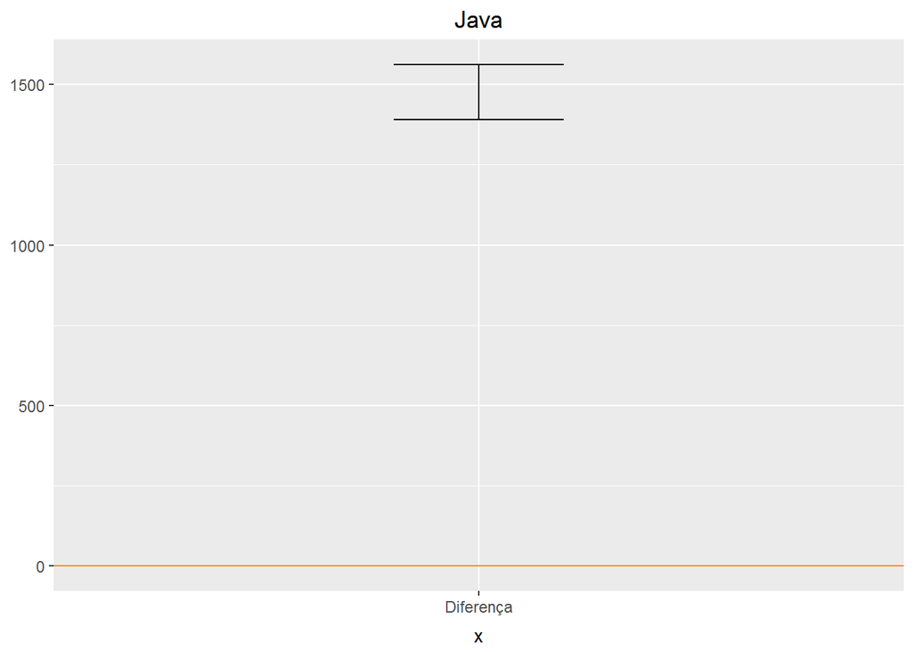

```r
java_repos_wkday <- java_repos_wkday %>%
  mutate(isWeekend = FALSE)
java_repos_wkend <- java_repos_wkend %>%
  mutate(isWeekend = TRUE)

java_merge = rbind(java_repos_wkday, java_repos_wkend)

java_diff_median = java_merge$users %>% bootstrap2(statistic=median,
                                         treatment=java_merge$isWeekend)
java_diff_CI = CI.percentile(java_diff_median, probs=c(.025, .975))

data.frame(java_diff_CI) %>%
   ggplot(aes(x= "Diferença", ymin = X2.5., ymax = X97.5.)) +
   geom_errorbar(width = .2) + ggtitle("Java") + theme(plot.title = element_text(hjust = 0.5)) +
   geom_hline(yintercept = 0, colour = "darkorange")
```

Para Java a diferenca na mediana da popularidade nos dias de semana e final de semana, também com uma confiança de 95%, podemos afirmar que o intervalo está entre [1391~1562], onde nos dias de semana Java é mais popular que nos finais de semana.

## 2. Existe uma diferença significativa entre as duas linguagens na sua variação de popularidade nos finais de semana?

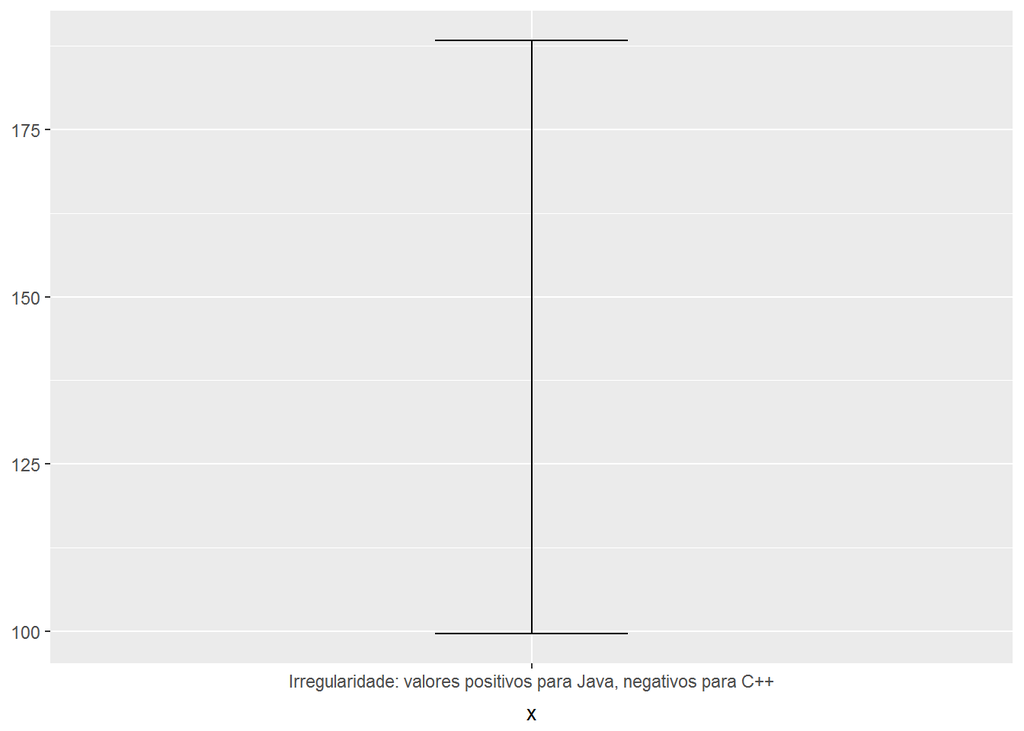

```r
cpp_java.SD <- bootstrap2(data = (java_repos_wkend)$users,
               data2 = (cpp_repos_wkend)$users,
               sd)

cpp_java.SD.CI = CI.percentile(cpp_java.SD, probs = c(.025, .975))

data.frame(cpp_java.SD.CI) %>%
  ggplot(aes(x = "Irregularidade: valores positivos para Java, negativos para C++", ymin = X2.5., ymax = X97.5.)) +
  geom_errorbar(width = .2)
```

Usando o mesmo processo que os utilizados previamente, porém, calculando a diferença entre os desvios padrão com uma confiança de 95% chegamos a seguinte conclusão: com o intervalo acima conseguimos ver que existe uma diferenca significativa onde Java possui irregularidade muito maior que a de C++ entre alteracoes nos arquivos em dias de semana e final de semana. Com uma confiança de 95% podemos dizer que essa diferença de desvio padrao esta no intervalo [101~189].